# maps_neotomaWorkshop

#### Results

```
##  [1] "age"             "agetype"         "ageolder"        "ageyounger"
##  [5] "chronologyid"    "chronologyname"  "units"           "value"
##  [9] "context"         "element"         "taxonid"         "symmetry"
## [13] "taxongroup"      "elementtype"     "variablename"    "ecologicalgroup"
## [17] "analysisunitid"  "sampleanalyst"   "sampleid"        "depth"
## [21] "thickness"       "samplename"      "datasetid"       "database"
## [25] "datasettype"     "age_range_old"   "age_range_young" "age_units"
## [29] "recdatecreated"  "datasetnotes"    "siteid"          "sitename"
## [33] "lat"             "long"            "area"            "sitenotes"
## [37] "description"     "elev"            "collunitid"
```

```
##  [1] "age"             "agetype"         "ageolder"        "ageyounger"
##  [5] "chronologyid"    "chronologyname"  "units"           "value"
##  [9] "context"         "element"         "taxonid"         "symmetry"
## [13] "taxongroup"      "elementtype"     "variablename"    "ecologicalgroup"
## [17] "analysisunitid"  "sampleanalyst"   "sampleid"        "depth"
## [21] "thickness"       "samplename"      "datasetid"       "database"
## [25] "datasettype"     "age_range_old"   "age_range_young" "age_units"
## [29] "recdatecreated"  "datasetnotes"    "siteid"          "sitename"
## [33] "lat"             "long"            "area"            "sitenotes"
## [37] "description"     "elev"            "collunitid"      "proportion"
```

```
##   age           agetype ageolder ageyounger chronologyid  chronologyname units
## 1  NA Calendar years BP      -18        -33         9775 Collection date  <NA>
## 2  NA Calendar years BP      -18        -33         9794 Collection date  <NA>
## 3  NA Calendar years BP      -18        -33         9780 Collection date  <NA>
## 4 -57 Calendar years BP       NA         NA        27719 Collection date units
## 5 -57 Calendar years BP       NA         NA        27719 Collection date units
## 6  NA Calendar years BP      -32        -35        38564 Collection date units
##   value context element taxonid symmetry      taxongroup elementtype
## 1  8.20    <NA>    <NA>   21266       NA Water chemistry        <NA>
## 2  6.30    <NA>    <NA>   21266       NA Water chemistry        <NA>
## 3  6.00    <NA>    <NA>   21266       NA Water chemistry        <NA>
## 4  8.65    <NA>   field   21266       NA Water chemistry       field
## 5  8.83    <NA>     lab   21266       NA Water chemistry         lab
## 6  8.98    <NA>   field   21266       NA Water chemistry       field
##   variablename ecologicalgroup analysisunitid           sampleanalyst sampleid
```

[output cut: 34 more lines]

```
## # A tibble: 6 × 40
##     age agetype      ageolder ageyounger chronologyid chronologyname units value
##   <dbl> <chr>           <dbl>      <dbl>        <int> <chr>          <chr> <dbl>
## 1 -33   Calendar ye…    -31.1      -34.9        19161 Deep L Core 1  NISP     62
## 2 -33   Calendar ye…    -31.1      -34.9        19161 Deep L Core 1  NISP    186
## 3 -33   Calendar ye…    -31.1      -34.9        19161 Deep L Core 1  NISP    187
## 4 -24.4 Calendar ye…    -22.6      -26.2        19161 Deep L Core 1  NISP     68
## 5 -24.4 Calendar ye…    -22.6      -26.2        19161 Deep L Core 1  NISP    137
## 6 -24.4 Calendar ye…    -22.6      -26.2        19161 Deep L Core 1  NISP    203
## # ℹ 32 more variables: context <chr>, element <chr>, taxonid <int>,
## #   symmetry <lgl>, taxongroup <chr>, elementtype <chr>, variablename <chr>,
## #   ecologicalgroup <chr>, analysisunitid <int>, sampleanalyst <chr>,
## #   sampleid <int>, depth <dbl>, thickness <dbl>, samplename <chr>,
## #   datasetid <int>, database <chr>, datasettype <chr>, age_range_old <dbl>,
## #   age_range_young <dbl>, age_units <chr>, recdatecreated <date>,
## #   datasetnotes <chr>, siteid <int>, sitename <chr>, lat <dbl>, long <dbl>, …
```

[output not shown]

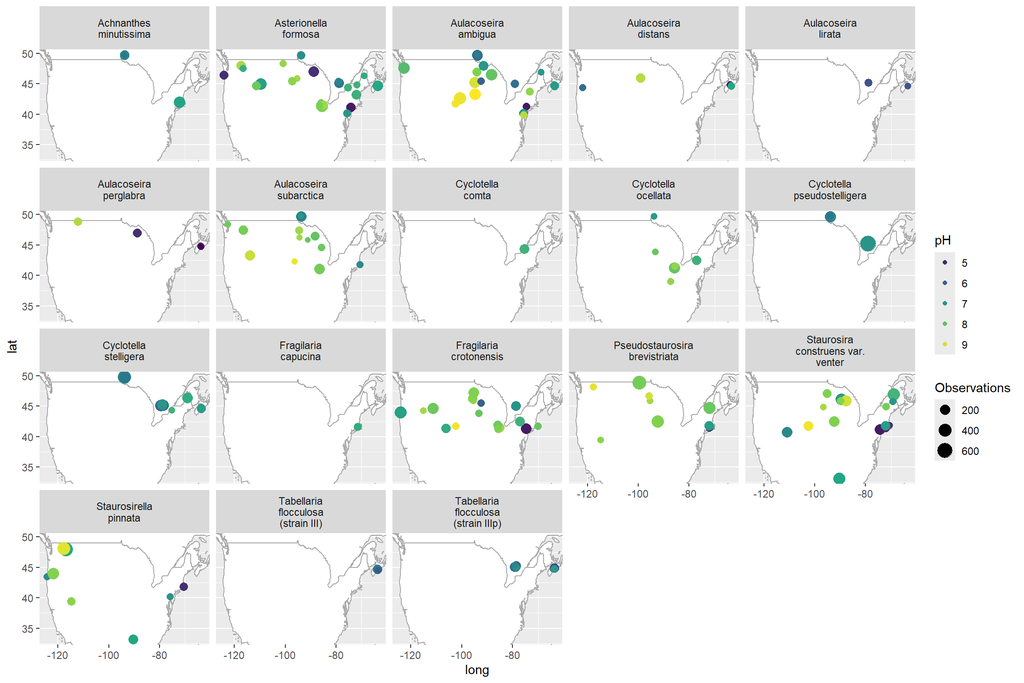

This code is modified from a previous version of “A Simple Workflow:”

### 4.3. Distributions in Climate (July max temperature) from Rasters

We are often interested in the interaction between taxa and climate, assuming that time is a proxy for changing environments. The development of large-scale global datasets for climate has made it relatively straightforward to access data from the cloud in raster format. R provides a number of tools (in the `sf` and `raster` packages) for managing spatial data, and providing support for spatial analysis of data.

The first step is taking our sample data and turning it into a spatial object using the `sf` package in R:

```r
modern <- aggData_samples_diatom %>%
  filter(age < 1000) %>%
  filter(ecologicalgroup == "DIAT" & elementtype == "valve" & units == "NISP")

spatial <- sf::st_as_sf(modern,
                        coords = c("long", "lat"),
                        crs = "+proj=longlat +datum=WGS84")
```

The data is effectively the same, `sf` makes an object called `spatial` that is a `data.frame` with all the information from `samples()`, and a column (`geometry`) that contains the spatial data.

We can use the [`worldclim_global()` function](https://search.r-project.org/CRAN/refmans/geodata/html/worldclim.html) in the `geodata` package to get climate data from WorldClim (geodata also has many other types of global data available!). The operations that follow here can be applied to any sort of raster data, provided it is loaded into R as a `raster` object.

You can load several types of monthly average climate data from WorldClim:

| Variable | Description | Unit |
| --- | --- | --- |
| tmin | minimum temperature | °C |
| tmax | maximum temperature | °C |
| tavg | average temperature | °C |
| prec | total precipitation | mm |
| srad | incident solar radiation | kJ m-2 day-1 |
| wind | wind speed (2 m above the ground) | m s-1 |
| vapr | vapor pressure | kPa |

Here we pull in the raster data, at a 10 minute (spatial, not temporal) resolution for the $T_{max}$ and $T_{min}$, maximum and minimum monthly temperatures, respectively. The raster itself has 12 layers, one for each month. We’ll use the `extract()` function to just get the maximum temperature for July, and the minimum temperature for February (roughly, the max in the hottest month and min in the coldest month).

```r
#worldTmax <- raster::getData('worldclim', var = 'tmax', res = 10)
worldTmax <- worldclim_global(var = "tmax", res = 10, path = tempdir(), version="2.1")
```

```
## Cached as: C:\Users\zk326\AppData\Local\Temp\RtmpMvOcq5/climate/wc2.1_10m/wc2.1_10m_tmax.zip
```

```r
worldTmin = worldclim_global(var = "tmin", res = 10, path = tempdir(), version="2.1")
```

```
## Cached as: C:\Users\zk326\AppData\Local\Temp\RtmpMvOcq5/climate/wc2.1_10m/wc2.1_10m_tmin.zip
```

```r
spatial$tmax7 <- raster::extract(worldTmax, spatial)[,7]
spatial$tmin2 <- raster::extract(worldTmin, spatial)[,2]
```

```r
spatial2 <- spatial %>%
  mutate(variablename = stringr::str_replace(variablename, "[[:punct:]]", " ")) %>%
  mutate(variablename = stringr::word(variablename, 1)) %>%
  group_by(variablename, siteid, sitename) %>%
  summarise(tmax7 = max(tmax7),
            tmin2 = min(tmin2),
            count_sum = sum(value),
            .groups = "keep") %>%
  mutate(trange = tmax7-tmin2) %>%
  group_by(variablename) %>%
  filter(n() > 20)
```

#### 4.3.1. Taxa specific mapping

Let’s take a look (and map) some data for a specific genus: Aulacoseira. First, we’ll plot it with ggplot2, and then with Leaflet.

```r
aul <- spatial2 %>%
  filter(variablename == "Aulacoseira")

head(aul)
```

```
## # A tibble: 6 × 8
## # Groups:   variablename [1]
##   variablename siteid sitename  tmax7  tmin2 count_sum             geometry
##   <chr>         <int> <chr>     <dbl>  <dbl>     <dbl>          <POINT [°]>
## 1 Aulacoseira   13319 Crow Hill  26.0  -6.23       137  (-75.7436 40.13763)
## 2 Aulacoseira   13321 Georgia …  26.5  -5.44       117 (-75.65335 39.94468)
## 3 Aulacoseira   14006 Kelly La…  21.9 -17.2        122 (-78.61959 45.24779)
## 4 Aulacoseira   14007 Kennisis…  21.9 -17.2         60 (-78.64233 45.20661)
## 5 Aulacoseira   14008 Kushog L…  22.3 -16.4        137 (-78.81045 45.08767)
## 6 Aulacoseira   14009 Little C…  21.8 -16.7         35 (-79.01091 45.40383)
## # ℹ 1 more variable: trange <dbl>
```

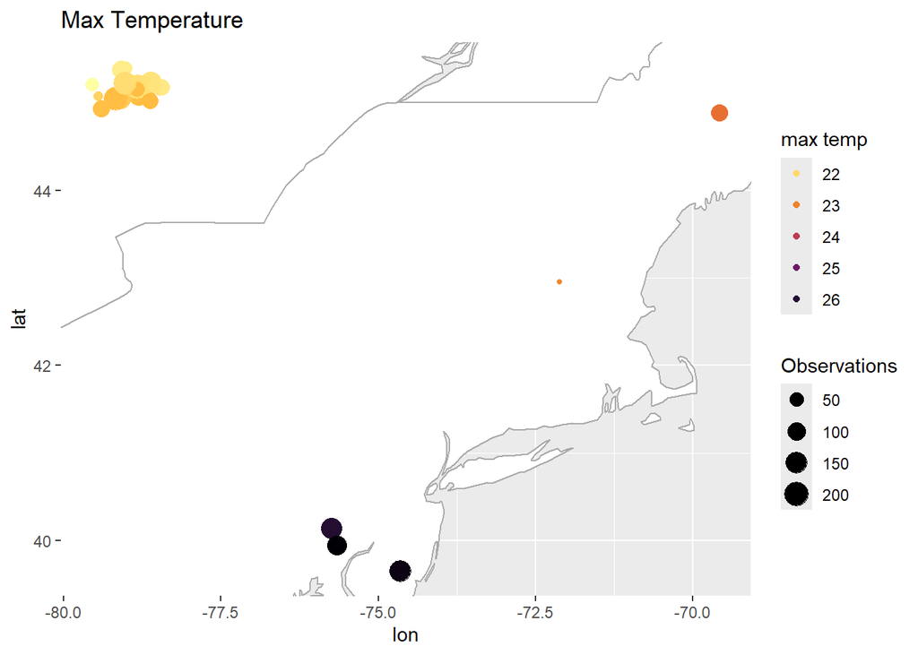

```r
aul2 <- aul %>%
  mutate(lon = sf::st_coordinates(geometry)[,1],
         lat = sf::st_coordinates(geometry)[,2])

ggplot() +
  annotation_map(
    map_data("world"),
    fill = "white", colour = "darkgrey"
  ) +
  geom_point(data = aul2, aes(x =lon,
                              y =lat,
                              size = count_sum,
                              color = tmax7))+
  scale_color_viridis_c(option = "inferno", direction = -1) +
  guides(color = guide_legend("max temp"),
         size = guide_legend("Observations"))+
  labs(title = "Max Temperature")
```

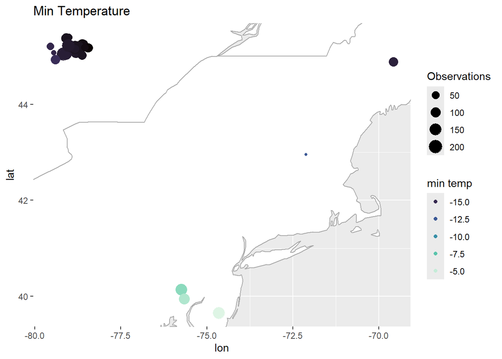

```r
ggplot() +
  annotation_map(
    map_data("world"),
    fill = "white", colour = "darkgrey"
  ) +
  geom_point(data = aul2, aes(x =lon,
                              y =lat,
                              size = count_sum,
                              color = tmin2))+
  scale_color_viridis_c(option = "mako") +
  guides(color = guide_legend("min temp"),
         size = guide_legend("Observations"))+
  labs(title = "Min Temperature")
```

```r
# leaflet map
# set up palettes
pal_hot <- leaflet::colorBin("inferno",
                            domain = aul2$tmax7,
                            bins = 5,
                            reverse = TRUE)

pal_cold <- leaflet::colorBin("mako",
                            domain = aul2$tmin2,
                            bins = 5)

aul_tmax <- leaflet(aul2) %>%
  addTiles() %>%
  addCircleMarkers(lng = aul2$lon,
                   lat = aul2$lat,
                   radius = ~ scales::rescale(aul2$count_sum, to = c(5,30)),
                   color = pal_hot(aul2$tmax7),
                   popup = paste0("<b>", aul2$sitename,
                                  "</b><br><a href=",
                                  explorerURL, "?siteids=",
                                  aul2$siteid,
                                  ">Explorer Link</a>",
                                  "<br> <b>Max temp: </b>",
                                  round(aul2$tmax7,2),
                                  "<br> <b>Min temp: </b>",
                                  round(aul2$tmin2,2),
                                  "<br><b>Observations: </b>",
                                  aul2$count_sum),
                   options = markerOptions(riseOnHover = TRUE)) %>%
  addLegend("bottomright",
            pal = pal_hot,
            values = ~tmax7,
            title = "Max Temperature in July",
            opacity = 1)

aul_tmin <- leaflet(aul2) %>%
  addTiles() %>%
  addCircleMarkers(lng = aul2$lon,
                   lat = aul2$lat,
                   radius = ~ scales::rescale(aul2$count_sum, to = c(5,30)),
                   color = pal_cold(aul2$tmin2),
                   popup = paste0("<b>", aul2$sitename,
                                  "</b><br><a href=",
                                  explorerURL, "?siteids=",
                                  aul2$siteid,
                                  ">Explorer Link</a>",
                                  "<br> <b>Max temp: </b>",
                                  round(aul2$tmax7,2),
                                  "<br> <b>Min temp: </b>",
                                  round(aul2$tmin2,2),
                                  "<br><b>Observations: </b>",
                                  aul2$count_sum),
                   options = markerOptions(riseOnHover = TRUE)) %>%
  addLegend("bottomright",
            pal = pal_cold,
            values = ~tmin2,
            title = "Min Temperature in February",
            opacity = 1)

aul_tmax
```

[interactive chart not shown]

```r
aul_tmin
```

[interactive chart not shown]